# Introduction to Pandas

Rajesh Majumder

March 18, 2023

- pandas provides rich data structures and functions designed to make working with structured data fast, easy, and expressive.
- The primary object in pandas are DataFrame,a twodimensional tabular, column-oriented data structure with both row and column labels
- It has functions for analyzing, cleaning, exploring, and manipulating data.
- The name "Pandas" has a reference to both "Panel Data", and "Python Data Analysis" and was created by Wes McKinney in 2008.

## Installation of Pandas

Install it using this command:(*write the command on the command python command prompt/ ANACONDA prompt*)

`pip install pandas`

or

`conda install pandas`

## Checking Pandas Version

The version string is stored under `__version__` attribute.

```python
import pandas as pd

print(pd.__version__)
```

```
1.4.4
```

## Create a simple data frame

- (step:1) First creating a dictionary
- (step:2) Then converting it into data frame

```python
mydict = {
  'student': ["Arnab", "Mainak", "Kunal","Sourav"],
  'Age': [24,25,25,26]
}
type(mydict)
```

```
dict
```

```python
mydat= pd.DataFrame(mydict)
mydat
```

|  | student | Age |
| --- | --- | --- |
| 0 | Arnab | 24 |
| 1 | Mainak | 25 |
| 2 | Kunal | 25 |
| 3 | Sourav | 26 |

```python
type(mydat)
```

```
pandas.core.frame.DataFrame
```

**Similarly, using numpy we can also create a data drame just like this:**

```python
import numpy as np
```

```python
# Here, np.arange(0,20).reshape(5,4) is creating a 2D array i.e., a matrix with dim (5x4).

df= pd.DataFrame(np.arange(0,20).reshape(5,4),index=None,columns=["Colm1","Colm2","Colm3","Colm4"])
print(df)
type(df)
```

```
   Colm1  Colm2  Colm3  Colm4
0      0      1      2      3
1      4      5      6      7
2      8      9     10     11
3     12     13     14     15
4     16     17     18     19
```

```
pandas.core.frame.DataFrame
```

## Pandas Series

- A Pandas Series is like a **column in a table**.
- It is a **one-dimensional array** holding data of any type.

```python
a=[1,2,3,4,5]
s1= pd.Series(a)
s1
```

```
0    1
1    2
2    3
3    4
4    5
dtype: int64
```

```python
type(s1)
```

```
pandas.core.series.Series
```

## Accessing elements of a Data frame

there are two ways for accessing elements of a dataframe:

1> `loc`

2> `iloc`

- `loc` returns one or more specified row(s).
- `iloc` returns one or more specified row(s) & column(s).

```python
df.loc[0] ##1st row of the df
```

```
Colm1    0
Colm2    1
Colm3    2
Colm4    3
Name: 0, dtype: int32
```

```python
type(df.loc[0])
```

```
pandas.core.series.Series
```

```python
df.loc[[0,1]]
```

|  | Colm1 | Colm2 | Colm3 | Colm4 |
| --- | --- | --- | --- | --- |
| 0 | 0 | 1 | 2 | 3 |
| 1 | 4 | 5 | 6 | 7 |

```python
type(df.loc[[0,1]])
```

```
pandas.core.frame.DataFrame
```

**Note:** when there is one rwo in `loc`, return type will be *series* & when there is more than one row, the returrn type will be *dataframe*.

```python
df.iloc[0,0] ## (1,1) element of df
```

```
0
```

```python
df.iloc[0:2,0:3] ## 1st 2 rows and three columns
```

|  | Colm1 | Colm2 | Colm3 |
| --- | --- | --- | --- |
| 0 | 0 | 1 | 2 |
| 1 | 4 | 5 | 6 |

```python
type(df.iloc[0:2,0:3])
```

```
pandas.core.frame.DataFrame
```

```python
df.iloc[:,0]
```

```
0     0
1     4
2     8
3    12
4    16
Name: Colm1, dtype: int32
```

```python
type(df.iloc[:,0])
```

```
pandas.core.series.Series
```

## Extracting some columns And Rows

Istated of using `loc` or `iloc` we can simple use the indexing

```python
df[0:2] # 1st two rows
```

|  | Colm1 | Colm2 | Colm3 | Colm4 |
| --- | --- | --- | --- | --- |
| 0 | 0 | 1 | 2 | 3 |
| 1 | 4 | 5 | 6 | 7 |

```python
df["Colm1"]
```

```
0     0
1     4
2     8
3    12
4    16
Name: Colm1, dtype: int32
```

```python
df[["Colm1","Colm2"]]
```

|  | Colm1 | Colm2 |
| --- | --- | --- |
| 0 | 0 | 1 |
| 1 | 4 | 5 |
| 2 | 8 | 9 |
| 3 | 12 | 13 |
| 4 | 16 | 17 |

## Converting dataframe to array

```python
df.values
```

```
array([[ 0,  1,  2,  3],
       [ 4,  5,  6,  7],
       [ 8,  9, 10, 11],
       [12, 13, 14, 15],
       [16, 17, 18, 19]])
```

```python
type(df.values)
```

```
numpy.ndarray
```

## Unique Values in a column

```python
df["Colm1"].value_counts()
```

```
0     1
4     1
8     1
12    1
16    1
Name: Colm1, dtype: int64
```

```python
type(df["Colm1"].value_counts())
```

```
pandas.core.series.Series
```

```python
df[["Colm1","Colm2"]].value_counts()
```

```
Colm1  Colm2
0      1        1
4      5        1
8      9        1
12     13       1
16     17       1
dtype: int64
```

```python
df2= pd.DataFrame(np.array([[1,2,3,4],
                          [2,4,7,9],
                          [6,4,5,7],
                          [5,5,7,9]]),columns=["colm1","colm2","colm3","colm4"])
df2
```

|  | colm1 | colm2 | colm3 | colm4 |
| --- | --- | --- | --- | --- |
| 0 | 1 | 2 | 3 | 4 |
| 1 | 2 | 4 | 7 | 9 |
| 2 | 6 | 4 | 5 | 7 |
| 3 | 5 | 5 | 7 | 9 |

```python
df2[["colm2","colm4"]].value_counts()
```

```
colm2  colm4
2      4        1
4      7        1
       9        1
5      9        1
dtype: int64
```

## Dimension or Shape of the Dataframe

```python
df.shape
```

```
(5, 4)
```

```python
df2.shape
```

```
(4, 4)
```

## Checking the NULL values or NA values

```python
df.isnull().sum() ## For NULL values
```

```
Colm1    0
Colm2    0
Colm3    0
Colm4    0
dtype: int64
```

```python
df.isna().sum()
```

```
Colm1    0
Colm2    0
Colm3    0
Colm4    0
dtype: int64
```

```python
df3= pd.DataFrame(np.array([[1,np.NaN,3,4],
                          [2,4,np.NaN,9],
                          [6,4,5,7],
                          [5,5,7,9]]),columns=["colm1","colm2","colm3","colm4"])
df3
```

|  | colm1 | colm2 | colm3 | colm4 |
| --- | --- | --- | --- | --- |
| 0 | 1.0 | NaN | 3.0 | 4.0 |
| 1 | 2.0 | 4.0 | NaN | 9.0 |
| 2 | 6.0 | 4.0 | 5.0 | 7.0 |
| 3 | 5.0 | 5.0 | 7.0 | 9.0 |

```python
df3.isna().sum()
```

```
colm1    0
colm2    1
colm3    1
colm4    0
dtype: int64
```

```python
df3.isnull().sum()
```

```
colm1    0
colm2    1
colm3    1
colm4    0
dtype: int64
```

## Read .CSV file

```python
iris=pd.read_csv("D:/Users/User/Downloads/iris.csv")

iris.head(5)
```

|  | Sepal.Length | Sepal.Width | Petal.Length | Petal.Width | Species |
| --- | --- | --- | --- | --- | --- |
| 0 | 5.1 | 3.5 | 1.4 | 0.2 | setosa |
| 1 | 4.9 | 3.0 | 1.4 | 0.2 | setosa |
| 2 | 4.7 | 3.2 | 1.3 | 0.2 | setosa |
| 3 | 4.6 | 3.1 | 1.5 | 0.2 | setosa |
| 4 | 5.0 | 3.6 | 1.4 | 0.2 | setosa |

## Data Info

```python
iris.info()
```

```
<class 'pandas.core.frame.DataFrame'>
RangeIndex: 150 entries, 0 to 149
Data columns (total 5 columns):
 #   Column        Non-Null Count  Dtype
---  ------        --------------  -----
 0   Sepal.Length  150 non-null    float64
 1   Sepal.Width   150 non-null    float64
 2   Petal.Length  150 non-null    float64
 3   Petal.Width   150 non-null    float64
 4   Species       150 non-null    object
dtypes: float64(4), object(1)
memory usage: 6.0+ KB
```

## Remove rows containing NA

```python
df3.dropna()
```

|  | colm1 | colm2 | colm3 | colm4 |
| --- | --- | --- | --- | --- |
| 2 | 6.0 | 4.0 | 5.0 | 7.0 |
| 3 | 5.0 | 5.0 | 7.0 | 9.0 |

## Multidimensional Indexing

Up to this point we’ve been focused primarily on one-dimensional and two-dimensional data, stored in Series and DataFrame objects, respectively.

Often it is useful to go beyond this and store higher-dimensional data that is, data indexed by more than one or two keys.

**Example:** *Suppose we would like to track data about states from two different years.*

Using the Pandas tools we’ve already covered i.e., we might be tempted to simply use Python tuples as keys:

```python
index = [('California', 2000), ('California', 2010),  ## Data index
         ('New York', 2000), ('New York', 2010),
         ('Texas', 2000), ('Texas', 2010)]

populations = [33871648, 37253956,                   ## Data vales
               18976457, 19378102,
               20851820, 25145561]


pop = pd.Series(populations, index=index)
pop
```

```
(California, 2000)    33871648
(California, 2010)    37253956
(New York, 2000)      18976457
(New York, 2010)      19378102
(Texas, 2000)         20851820
(Texas, 2010)         25145561
dtype: int64
```

But, accessing the values from this type is actually not the conveniant, it will be messy just like:

```python
# Now, if we want to access all data for 2010

pop[[i for i in pop.index if i[1] == 2010]]
```

```
(California, 2010)    37253956
(New York, 2010)      19378102
(Texas, 2010)         25145561
dtype: int64
```

So, instead of doing this we can use Pandas `MultiIndex`.

We can create a multi-index from the tuples as follows:

```python
index = pd.MultiIndex.from_tuples(index)

index
```

```
MultiIndex([('California', 2000),
            ('California', 2010),
            (  'New York', 2000),
            (  'New York', 2010),
            (     'Texas', 2000),
            (     'Texas', 2010)],
           )
```

Now, If we reindex our series(i.e., `pop`) with this MultiIndex, we see the *hierarchical representation* of the data:

```python
pop= pop.reindex(index)

pop
```

```
California  2000    33871648
            2010    37253956
New York    2000    18976457
            2010    19378102
Texas       2000    20851820
            2010    25145561
dtype: int64
```

```python
# Now to access all data for which the second index is 2010

pop[:,2010]
```

```
California    37253956
New York      19378102
Texas         25145561
dtype: int64
```

## Combining Datasets: Concat

Concatenation of Series and DataFrame objects is very similar to concatenation of NumPy arrays, which can be done via the `np.concatenate`

### Simple Concatenation with pd.concat

```python
## Concatenating two series

ser1 = pd.Series(['A', 'B', 'C'], index=[1, 2, 3])
ser2 = pd.Series(['D', 'E', 'F'], index=[4, 5, 6])
pd.concat([ser1, ser2])
```

```
1    A
2    B
3    C
4    D
5    E
6    F
dtype: object
```

#### (A) Concatenating two dataframe row-wise

```python
df1 = pd.DataFrame([["A1","B1"],
                    ["A2","B2"]],index=[1,2],columns=["A","B"])
print("df1:\n",df1,"\n")

df2 = pd.DataFrame([["A3","B4"],
                    ["A5","B6"]],index=[3,4],columns=["A","B"])
print("df2:\n",df2,"\n")


print("Concatenated Data:\n",pd.concat([df1, df2]))
```

```
df1:
     A   B
1  A1  B1
2  A2  B2

df2:
     A   B
3  A3  B4
4  A5  B6

Concatenated Data:
     A   B
1  A1  B1
2  A2  B2
3  A3  B4
4  A5  B6
```

#### (B) Concatenating two dataframe column-wise

```python
df1 = pd.DataFrame([["A1","B1"],
                    ["A2","B2"]],index=[1,2],columns=["A","B"])
print("df1:\n",df1,"\n")

df2 = pd.DataFrame([["C1","D1"],
                    ["C2","D2"]],index=[1,2],columns=["C","D"])
print("df2:\n",df2,"\n")


print("Concatenated Data:\n",pd.concat([df1, df2],axis=1))
```

```
df1:
     A   B
1  A1  B1
2  A2  B2

df2:
     C   D
1  C1  D1
2  C2  D2

Concatenated Data:
     A   B   C   D
1  A1  B1  C1  D1
2  A2  B2  C2  D2
```

## Aggregation and Grouping

An essential piece of analysis of large data is efficient summarization: computing aggregations like **sum, mean, median, min, and max, standard deviation, summary** etc.

**Listing of Pandas aggregation methods**

| Function | Description |
| --- | --- |
| `count()` | Total number of items |
| `first()`,`last()` | First and last item |
| `mean()`,`median()` | Mean and Median |
| `min()`, `max()` | Minimum and Maximum |
| `std()`, `var()` | Standard deviation and Variance |
| `mad()` | Mean absolute deviation |
| `prod()` | Product of all items |
| `sum()` | Sum of all items |
| `describe()` | Summary of Dataframe or Series |

```python
iris.iloc[:,:4].sum()/iris.shape[0]  ## Mean
```

```
Sepal.Length    5.843333
Sepal.Width     3.057333
Petal.Length    3.758000
Petal.Width     1.199333
dtype: float64
```

```python
iris.iloc[:,:4].mean()            ## Mean
```

```
Sepal.Length    5.843333
Sepal.Width     3.057333
Petal.Length    3.758000
Petal.Width     1.199333
dtype: float64
```

```python
iris.iloc[:,:4].describe()   ## Summary
```

|  | Sepal.Length | Sepal.Width | Petal.Length | Petal.Width |
| --- | --- | --- | --- | --- |
| count | 150.000000 | 150.000000 | 150.000000 | 150.000000 |
| mean | 5.843333 | 3.057333 | 3.758000 | 1.199333 |
| std | 0.828066 | 0.435866 | 1.765298 | 0.762238 |
| min | 4.300000 | 2.000000 | 1.000000 | 0.100000 |
| 25% | 5.100000 | 2.800000 | 1.600000 | 0.300000 |
| 50% | 5.800000 | 3.000000 | 4.350000 | 1.300000 |
| 75% | 6.400000 | 3.300000 | 5.100000 | 1.800000 |
| max | 7.900000 | 4.400000 | 6.900000 | 2.500000 |

## GroupBy

Simple aggregations can give you a flavor of your dataset, but often we would prefer to aggregate conditionally on some label or index: this is implemented in the socalled groupby operation.

A canonical example of this **split-apply-combine** operation, where the “apply” is a summation aggregation, is illustrated in the following diagram:

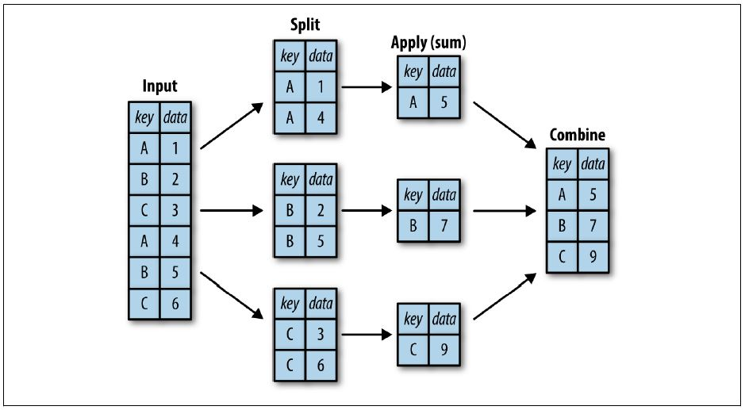

```python
iris.groupby("Species").min()
```

| Species | Sepal.Length | Sepal.Width | Petal.Length | Petal.Width |
| --- | --- | --- | --- | --- |
| setosa | 4.3 | 2.3 | 1.0 | 0.1 |
| versicolor | 4.9 | 2.0 | 3.0 | 1.0 |
| virginica | 4.9 | 2.2 | 4.5 | 1.4 |

Using the `describe()` method of DataFrames to perform a set of aggregations that describe each group in the data:

```python
iris.groupby("Species")["Sepal.Length"].describe()
```

| Species | count | mean | std | min | 25% | 50% | 75% | max |
| --- | --- | --- | --- | --- | --- | --- | --- | --- |
| setosa | 50.0 | 5.006 | 0.352490 | 4.3 | 4.800 | 5.0 | 5.2 | 5.8 |
| versicolor | 50.0 | 5.936 | 0.516171 | 4.9 | 5.600 | 5.9 | 6.3 | 7.0 |
| virginica | 50.0 | 6.588 | 0.635880 | 4.9 | 6.225 | 6.5 | 6.9 | 7.9 |